# Lesson 16

Timothy Luna

9/15/2019

# 3B-L1 Stereo Geometry

## Intro

This lesson is about what stereo and stereo geometry are. The next couple lectures are about how camera geometry and scene geometry relate to one another.

Stereo is a special case of having two particular views of an image. The relationship between two views can be used to reconstruct a scene.

How do stereo images relate to the scene?

## Why Multiple Views?

- Structure and depth are inherently ambiguous from a single view as we’re projecting from 3D to 2D. You lose information!
- Pushing down the leaning tower of Pisa, or holding up the Washington Monument come from the perspective projection issue!
- Multiple points can project along the same ray and therefore will strike the optical center at the same point along the same arc and will appear to be in the same place in the image.

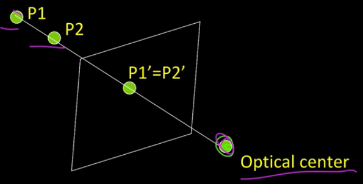

Collinear Projection

## Quiz: Depth and Shape Cues

What properties provide differences in depth or clues about an objects shape? Stereo is *not* the only thing at work, because we perceive depth from a flat display.

Shadows, texture, focus or blur, size, angles and lines, occlusion, are all additional cues of depth.

## How do Humans see in 3D?

- Perspective effects: We assume that all the houses are identically sized and therefore the apparent change in size provides the illusion of depth.
- Shading: Here we assume the mans skin has a particular reflectance and we use the reflected light to provide the illusion of depth. This is why certain kinds of makeup are used. Changing the shading changes apparent face shape.
- Texture: The changing of the texture elements on the wall provides the illusion of depth here. (Also the lighting and the position in the foreground.)
- Focus and Defocus: In real lenses there is a single focal plane of depth. The farther from that focal plane the more unfocused. You can use the change in focus in an image to provide the illusion of depth.
- Motion: This is related to stereo; a human being can use changes in objects observed from movement to fill in apparent depth. From a single eye if it moves you can discern shape. There’s an example of watching pixels move creating the illusion of a rotating cylinder.

[figure not shown]

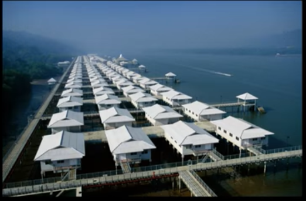

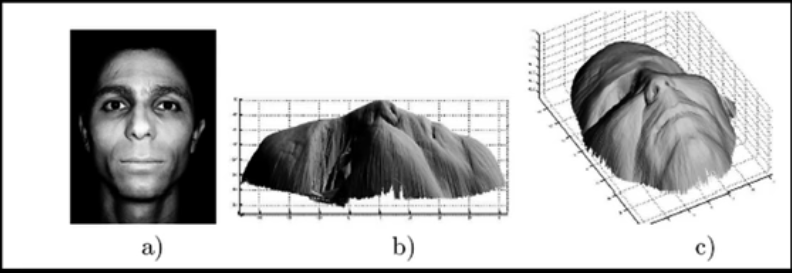

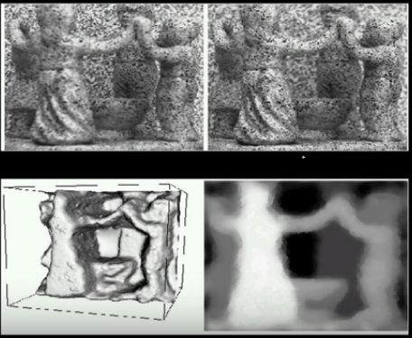

## Stereo

The general idea of estimating shape from some general cue was a big deal for some time and was referred to as “Shape from X” whether X be shading, texture, focus, motion, or whatever. It was popular in the 1980’s.

The fundamental idea was that from an image and some fundamental assumption about the world the brain could compute depth. We wanted to build machines that could do that but humans have *two* eyes! This is called stereo and involves two different sensors having slightly different views.

Stereo:

- The image from one eye is a little different than the image from the other eye.
- Think of shape from ‘motion’ between two views.
- Infer 3d shape of a scene from two (or more) images from different viewpoints.

Stereo photography was the idea of taking two slightly different images and showing each one to a different eye, which resulted in a 3d view. This was popular in the late 1800’s.

You could also make an anaglyph stereo composed of both red and blue imagery. Putting a red filter on one eye and a blue filter on another eye resulted in cheap 3d imagery!

Viewmasters! Heck yeah! I miss mine!

The basic premise was an image for each eye.

## Basic Idea

Two slightly different images have a foreground, a background, and a focus point. The focus point is where the convergence happens between the two images at some depth.

## Random Dot Stereograms

How do humans do stereo vision? Stereo can be done a few different ways.

1. Find like regions in each image and have the brain compare the shifted images.
2. Process the low level images to get depth and then overlay recognition.

Monocular recognition then fusion or binocular recognition…

This was tested in the 1960’s by creating a pair of synthetic images by spraying black dots on white objects. Pictures were taken from each side and two images were produced which were meaningless separate but together showed a raised block. Holy magic eye! These are called autostereograms and were popularized as Magic-Eye in the nineties.

Human binocular fusion is not based on matching large scale structure or individual processing. It’s based on a ow level process that directly fuses the two images.

## Estimating Depth with Stereo

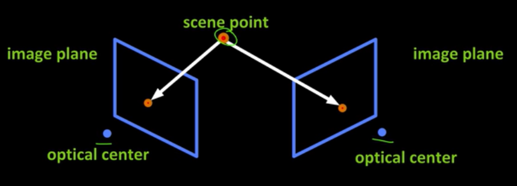

If I have two cameras (defined by their optical centers) looking at a single scene point and the individual points in each camera where the scene point exist can be corroborated and you can figure out which way the cameras are pointed you can determine the depth of the object.

What needs to be known?

- Image point correspondence.
- Information on camera pose (how are the cameras oriented in space with respect to one another, or calibration).

## Geometry for a Simple Stereo System

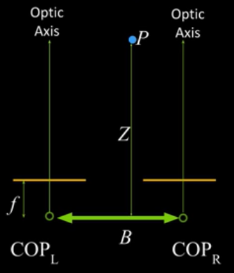

- Figure is looking down on the cameras and image planes
- The optic axes are parallel
- The image planes are coplanar.

Cameras are separated by a baseline $B$ and both have a focal length of $f$. Assume some point $P$ in the scene is located some distance $Z$ from the center of projection. That point projects into both the left and right images.

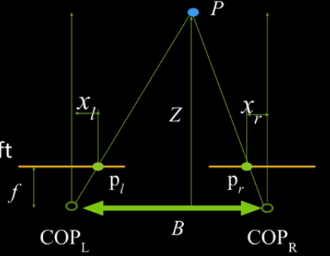

Notice that on the left the distance $x_l$ is positive and on the right $x_r$ is negative due to the definition of the axes / coordinate system. $p_l$ and $p_r$ are the points where the rays originating at $P$ intersect the focal plane.

So, what is the expression for Z? Time to pull out the old geometry. We can use similar triangles $(p_l, P, p_r)$ and $(C_l, P, C_r)$.

Using these we know that $\frac{B-x_l+x_r}{Z-f}=\frac{B}{Z}$. A little bit of algebra gives $Z=f\frac{B}{x_l-x_r}$ where $x_l-x_r$ is called the disparity. What happens when disparity is zero? Z is essentially infinity. That’s the inverse relationship between disparity and depth.

## Quiz: Left or Right

Given two images from a stereo setup where a man is in front of a tree, which is from the left and which the right?

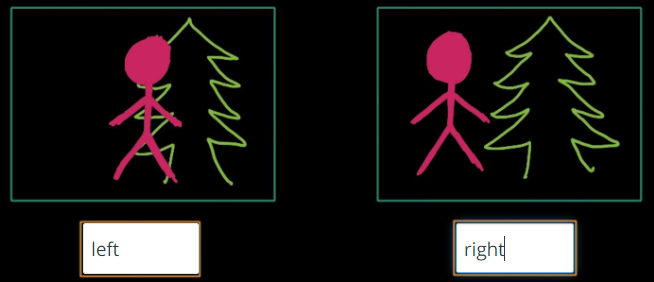

Remember the tree is *behind* the man. Think about a ray projecting from the tree. If you move the camera to the left the person will appear to move to the right, and vice-versa.

## Depth from Disparity

Some examples of disparity. One example is a building where the window is in different locations in each image. The disparity in each image can be used to create an image of a *disparity map* where the magnitude of the disparity is shown. The inverse relationship between disparity and depth is shown as close portions have higher disparity.

## Quiz: Stories in Stereo

Stereo images have been around for awhile. Have you seen innovative uses of stereo in computer vision? Some examples include estimating depth, or projections.

## End

Given calibrated cameras where you know the relationship between the two you can calculate the depth in two like images!